# Visualization (ggplot2, matplotlib, & seaborn)

Lecture 11

Dr. Colin Rundel

# Grammar of graphics

## The Grammar of Graphics

- Conceptualized by Leland Wilkinson in The Grammar of Graphics (1999)
- An attempt to taxonomize the basic elements of statistical graphics - what a plot is made of, independent of any particular chart type
- Adapted for R by Hadley Wickham as ggplot2 (2007)
  - a consistent and compact syntax for describing statistical graphics
  - highly modular - a plot is assembled from semantic components rather than picked from a menu of chart types
  - opinionated about how a plot is described, not about which plot to make
- The same ideas underlie plotnine (a port of ggplot2 to Python) and seaborn’s `objects` interface (end of the lecture)

## Components of a plot

A statistical graphic is a mapping of data variables to aesthetic attributes (position, color, size, shape, …) of geometric objects (points, lines, bars, …), possibly after a statistical transformation, drawn in a coordinate system and possibly split into facets.

| Component | Role | ggplot2 |
| --- | --- | --- |
| data | the data frame being plotted | `ggplot(data)` |
| aesthetics | which variables map to which visual properties | `aes()` |
| geometries | the visual objects that represent the data | `geom_*()` |
| statistics | transformations applied before drawing (counts, bins, model fits) | `stat_*()` |
| scales | how data values become aesthetic values (palettes, breaks, log) | `scale_*()` |
| facets | splitting the data into small multiples | `facet_*()` |
| coordinates | the coordinate system (Cartesian, flipped, polar, map) | `coord_*()` |
| theme | everything that is not data (fonts, gridlines, backgrounds) | `theme_*()`, `theme()` |

[figure not shown]

## Layers

A ggplot2 plot is a stack of layers drawn on shared scales, facets, and coordinates, with a theme on top. Each layer combines data and an aesthetic mapping with a geom, a stat, and a position adjustment.

```r
ggplot(
  data = [data frame],
  mapping = aes(x = , y = , ...)
) +
  geom_[type](
    aes(...), stat = , position =
  ) +
  geom_[type](...) +
  scale_[aes]_[type]() +
  facet_[type]() +
  coord_[type]() +
  theme_[name]()
```

Components are combined with `+`, not a pipe (ggplot2 predates both `%>%` and `|>`). A pipe would pass the plot as the geom’s first argument, `mapping`, which is an error. Piping data into `ggplot()` is fine.

## Data - Palmer penguins

```r
library(palmerpenguins)
(penguins = tidyr::drop_na(penguins))
```

```
# A tibble: 333 × 8
  species island    bill_length_mm bill_depth_mm flipper_length_mm body_mass_g
  <fct>   <fct>              <dbl>         <dbl>             <int>       <int>
1 Adelie  Torgersen           39.1          18.7               181        3750
2 Adelie  Torgersen           39.5          17.4               186        3800
3 Adelie  Torgersen           40.3          18                 195        3250
4 Adelie  Torgersen           36.7          19.3               193        3450
5 Adelie  Torgersen           39.3          20.6               190        3650
# ℹ 328 more rows
# ℹ 2 more variables: sex <fct>, year <int>
```

```python
penguins = pd.read_csv(
  "data/penguins.csv"
).dropna()
penguins
```

```
       species     island  bill_length_mm  ...  body_mass_g     sex  year
0       Adelie  Torgersen            39.1  ...       3750.0    male  2007
1       Adelie  Torgersen            39.5  ...       3800.0  female  2007
..         ...        ...             ...  ...          ...     ...   ...
342  Chinstrap      Dream            50.8  ...       4100.0    male  2009
343  Chinstrap      Dream            50.2  ...       3775.0  female  2009

[333 rows x 8 columns]
```

Rows with missing values are dropped so the examples avoid ggplot2’s “Removed n rows” warnings; `na.rm = TRUE` in a layer silences them for that layer.

## Data and mapping

`ggplot()` sets the default data and aesthetic mapping for every layer that follows. With no layers there is nothing to draw, but the `x` and `y` scales already exist.

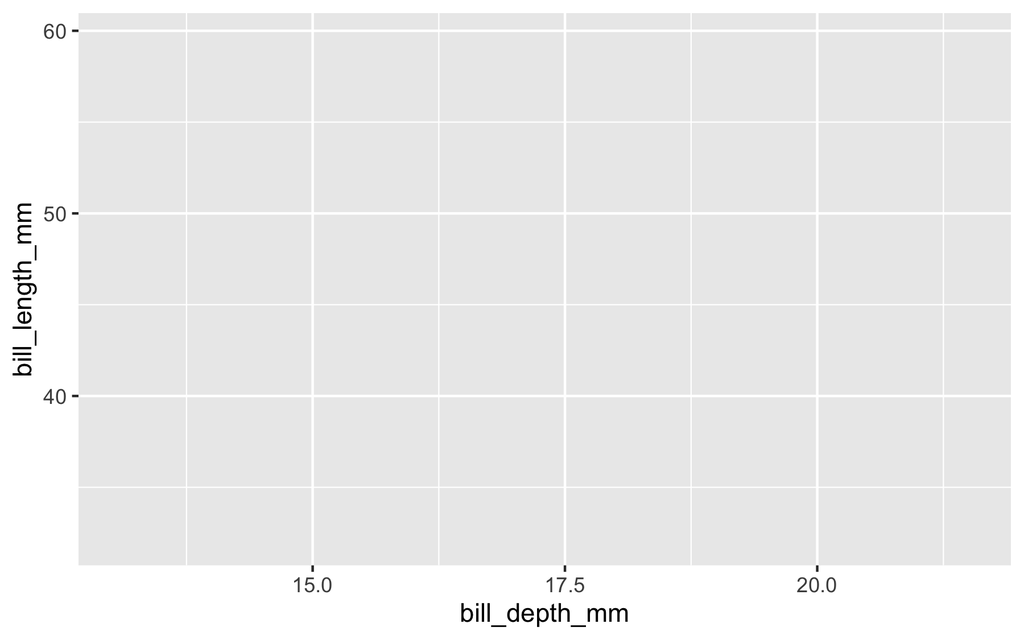

```r
ggplot(
  penguins,
  aes(
    x = bill_depth_mm,
    y = bill_length_mm
  )
)
```

## Adding a layer

`geom_point()` adds a layer with `+`. It inherits the data and mapping from `ggplot()`, applies its default stat (`"identity"`, which leaves the data alone), and draws one point per row.

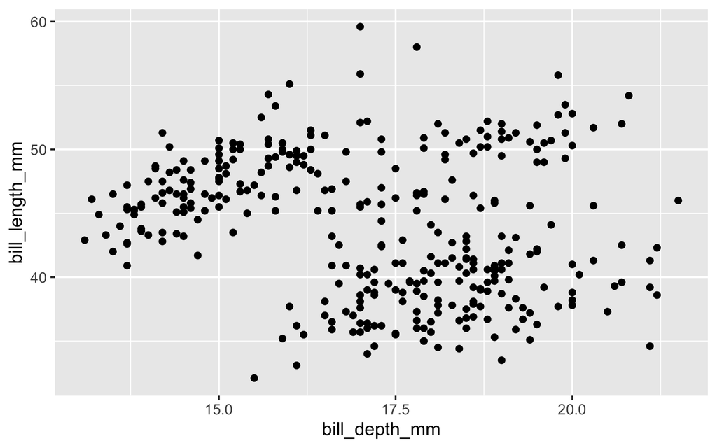

```r
ggplot(
  penguins,
  aes(
    x = bill_depth_mm,
    y = bill_length_mm
  )
) +
  geom_point()
```

## A second layer

`geom_smooth()` is a layer whose stat fits a model before drawing. The `color` mapping was given to `geom_point()` only, so the smooth layer knows nothing about species and fits one line to everything.

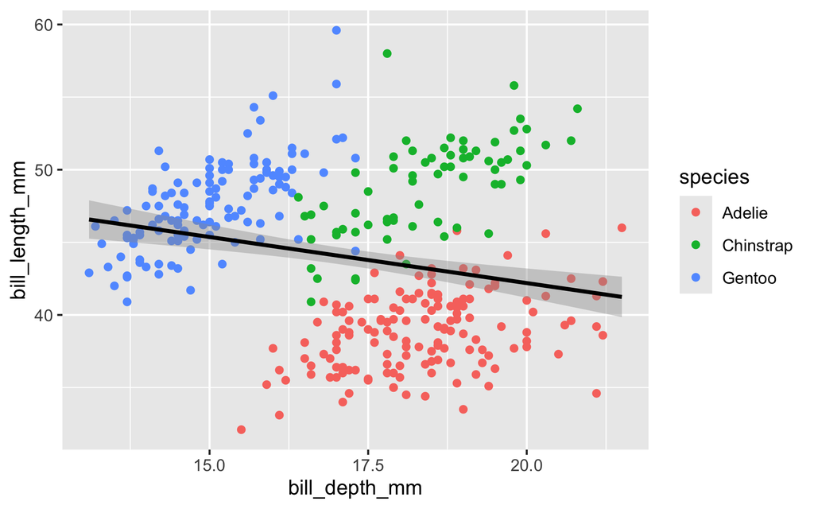

```r
ggplot(
  penguins,
  aes(
    x = bill_depth_mm,
    y = bill_length_mm
  )
) +
  geom_point(aes(color = species)) +
  geom_smooth(method = "lm", color="black")
```

## Inherited aesthetics

If we move `color = species` from `geom_point()` into `ggplot()`, how many regression lines will be fitted?

```r
ggplot(
  penguins,
  aes(
    x = bill_depth_mm,
    y = bill_length_mm,
    color = species
  )
) +
  geom_point() +
  geom_smooth(method = "lm")
```

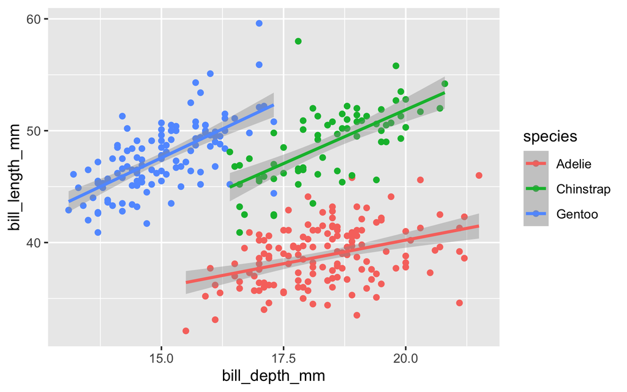

Moving the mapping into `ggplot()` makes it part of every layer. Each layer’s stat is computed per group, so there is now one fit per species and the overall negative trend reverses within each (Simpson’s paradox).

## Other details

Scales, facets, labels, and the theme are not layers. They are also added with `+` but apply to the whole plot.

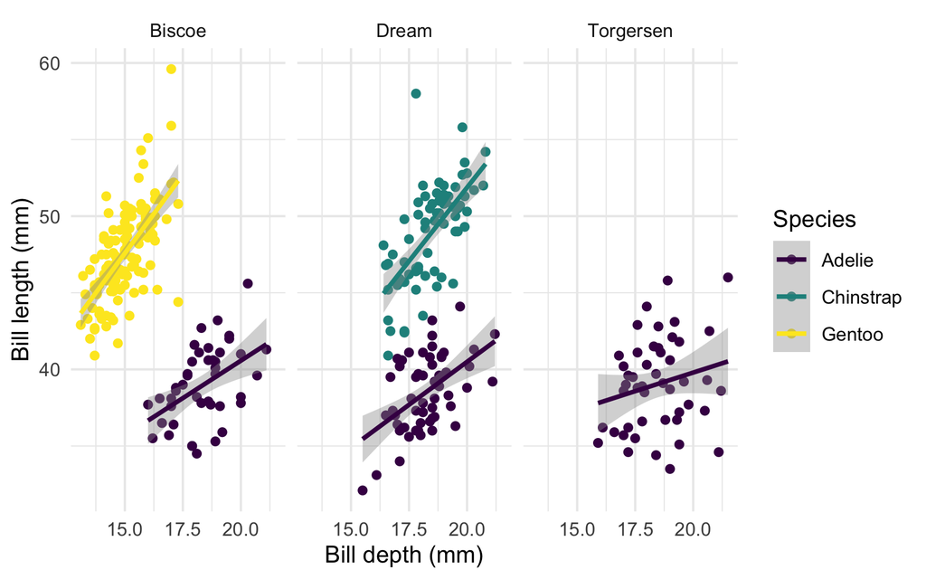

```r
ggplot(
  penguins,
  aes(
    x = bill_depth_mm,
    y = bill_length_mm,
    color = species
  )
) +
  geom_point() +
  geom_smooth(method = "lm") +
  facet_wrap(~ island) +
  scale_color_viridis_d() +
  labs(
    x = "Bill depth (mm)",
    y = "Bill length (mm)",
    color = "Species"
  ) +
  theme_minimal()
```

## Mappings vs settings

Anything inside `aes()` is a mapping: the aesthetic varies with a variable in the data and gets a scale and a legend.

Anything outside `aes()` is a setting: a constant applied to the whole layer.

```r
p = ggplot(penguins, aes(x = bill_depth_mm, y = bill_length_mm))
```

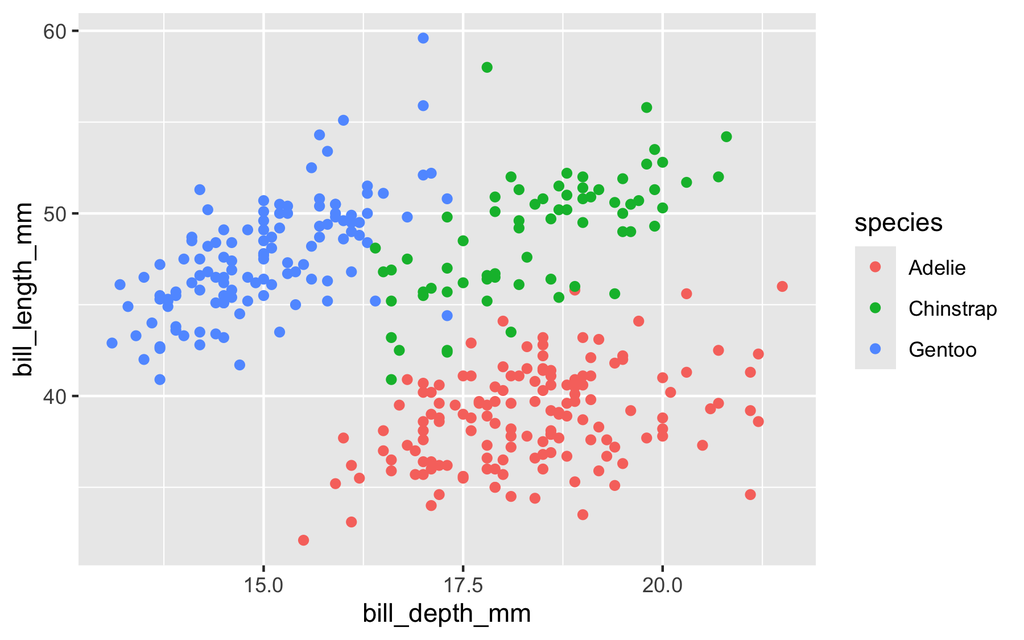

```r
p + geom_point(
  aes(color = species)
)
```

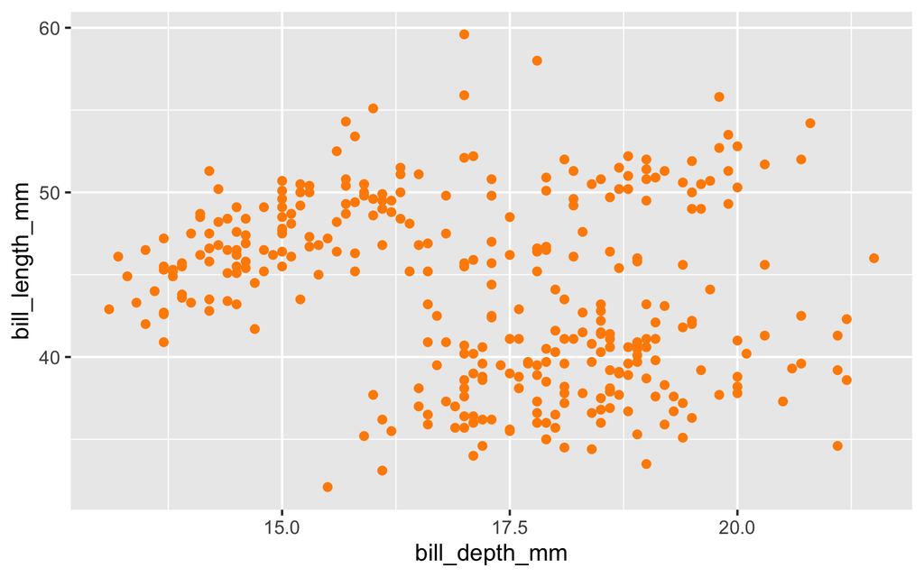

```r
p + geom_point(
  color = "darkorange"
)
```

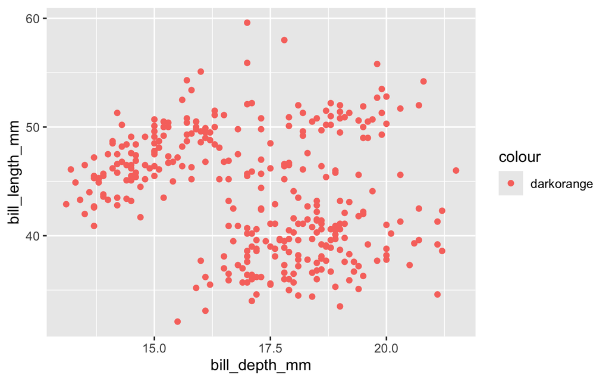

```r
p + geom_point(
  aes(color = "darkorange")
)
```

The last plot is a common mistake: inside `aes()` the string is data, so it is mapped to the first color of the default palette and given a legend entry named `darkorange`.

## Data masking in `aes()`

`aes()` captures its arguments and evaluates them in each layer’s data, the same data masking used by dplyr’s verbs. So a mapping can be any expression of the columns, and a column name stored in a variable needs the `.data` pronoun.

```r
p = ggplot(penguins, aes(y = body_mass_g))
```

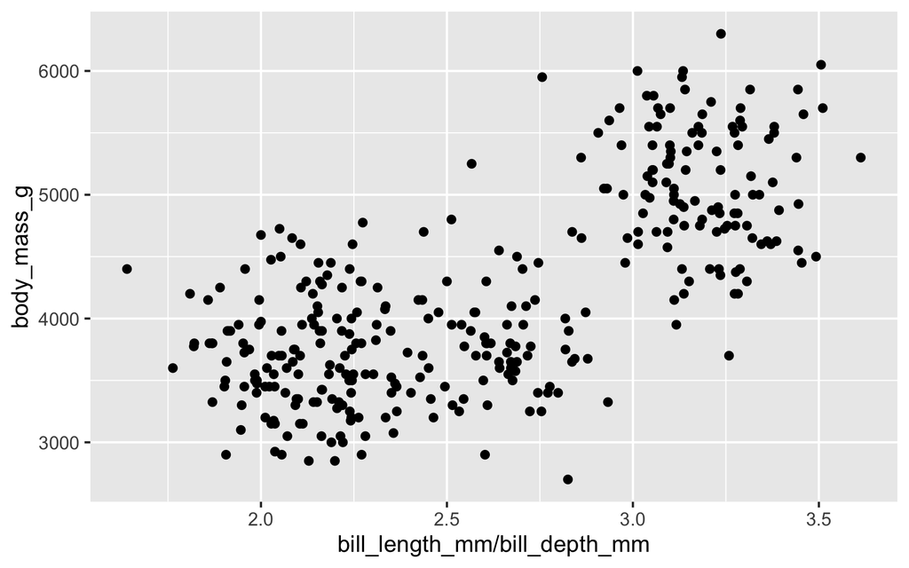

```r
p + geom_point(
  aes(
    x = bill_length_mm / bill_depth_mm
  )
)
```

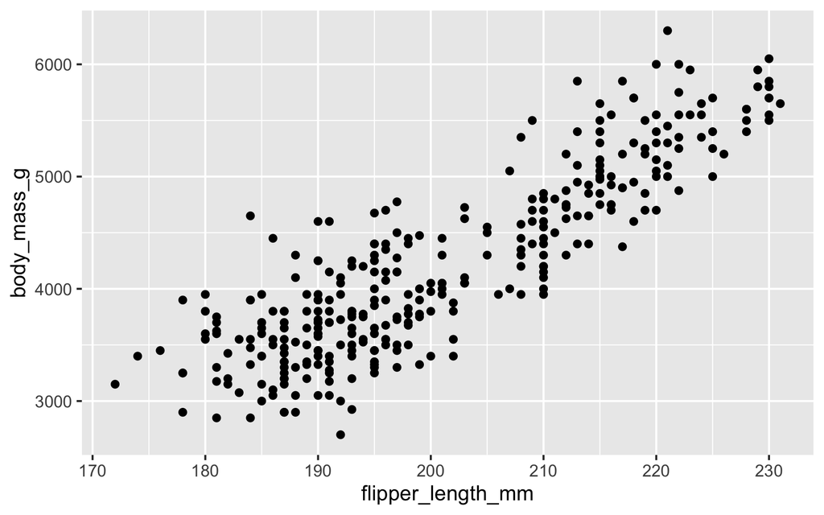

```r
v = "flipper_length_mm"

p + geom_point(
  aes(x = .data[[v]])
)
```

## ggplot objects

`ggplot()` returns an object describing the plot; nothing is drawn until it is printed. So a plot can be assigned, extended with `+`, stored in a list, returned from a function, or written to a file.

```r
p = ggplot(
  penguins,
  aes(
    x = flipper_length_mm,
    y = body_mass_g
  )
) +
  geom_point()
```

```r
class(p)[1]
```

```
[1] "ggplot2::ggplot"
```

```r
length(p@layers)
```

```
[1] 1
```

```r
ggsave(
  "penguins.png", p,
  width = 6, height = 4
)
```

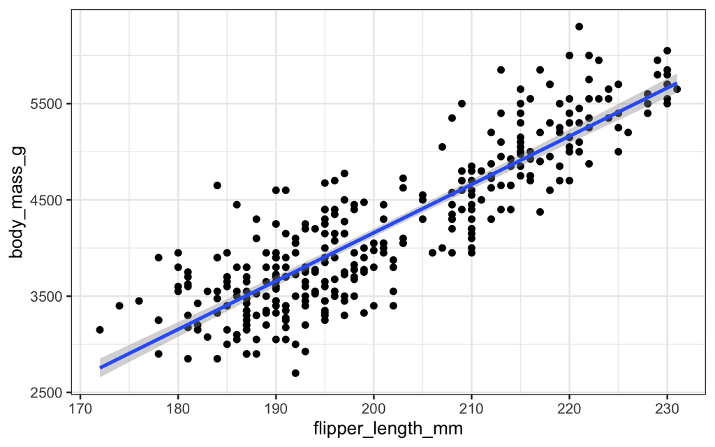

```r
p + geom_smooth(method = "lm") +
  theme_bw()
```

As of ggplot2 4.0, plots are S7 objects (S7 is R’s newest OOP system, successor to S3 and S4), so their components are properties accessed with `@`, e.g. `p@layers` or `p@data`.

## The rest of ggplot2

We will not tour the geoms. The package [reference](https://ggplot2.tidyverse.org/reference/) page is organized by the components above (layers, scales, guides, facets, coordinates, themes) and is the place to find what exists and which aesthetics each one understands.

[interactive chart not shown]

See also the [ggplot2 book](https://ggplot2-book.org/), [R4DS](https://r4ds.hadley.nz/visualize.html), the [cheatsheet](https://rstudio.github.io/cheatsheets/html/data-visualization.html), and the [extension gallery](https://exts.ggplot2.tidyverse.org/gallery/).

# matplotlib

## matplotlib & pyplot

> Matplotlib is a comprehensive library for creating static, animated, and interactive visualizations in Python.

> `matplotlib.pyplot` is a collection of functions that make matplotlib work like MATLAB. Each `pyplot` function makes some change to a figure: e.g., creates a figure, creates a plotting area in a figure, plots some lines in a plotting area, decorates the plot with labels, etc.

```python
import matplotlib as mpl
import matplotlib.pyplot as plt
mpl.__version__
```

```
'3.11.2'
```

seaborn, plotnine, and pandas’ default plotting backend draw with matplotlib, so its objects and vocabulary show up even when it is never called directly.

## Anatomy of a figure

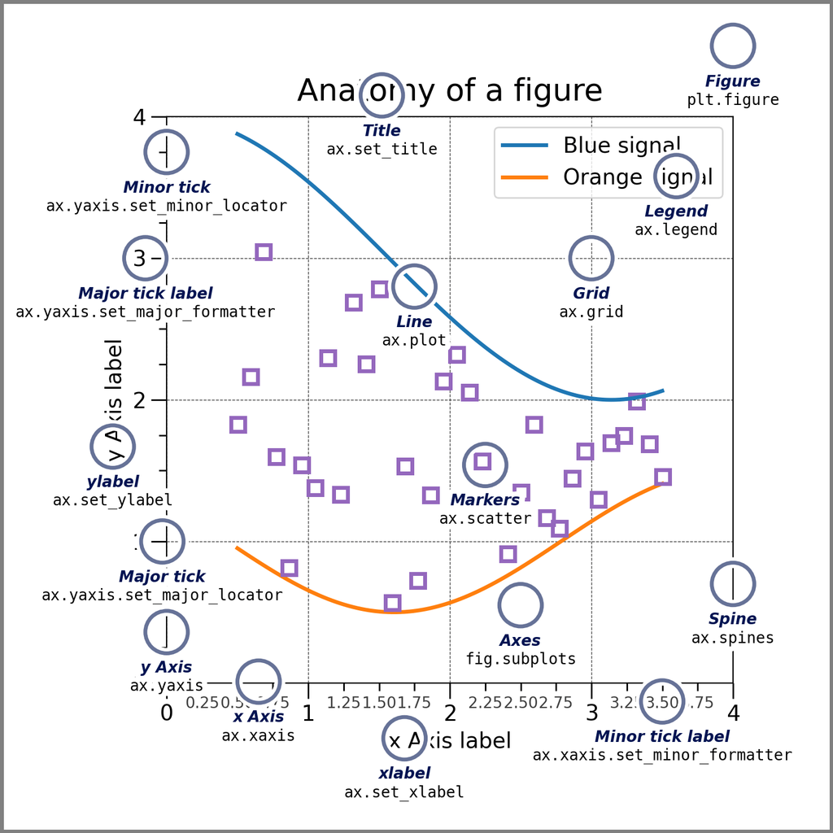

- Figure: the whole canvas, holding one or more Axes plus figure-wide titles and legends
- Axes: one plot (a panel or subplot), the data region together with its x and y Axis, title, labels, and legend. Nearly all plotting methods live here.
- Axis: a single number line (`ax.xaxis`, `ax.yaxis`) with its limits, ticks, and tick labels
- Artist: the base class for every drawn object. Figure, Axes, and Axis are Artists, and so are the lines, markers, patches, and text that plotting methods add.

Axes (the panel) and axis (the number line) are different things, which is a common source of confusion.

## Two interfaces

Implicit (pyplot):

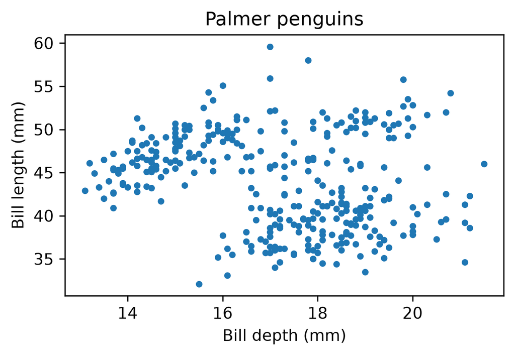

```python
plt.figure(figsize=(5, 3))
plt.scatter(
  "bill_depth_mm", "bill_length_mm",
  data=penguins, s=10
)
plt.xlabel("Bill depth (mm)")
plt.ylabel("Bill length (mm)")
plt.title("Palmer penguins")
```

Explicit (object-oriented):

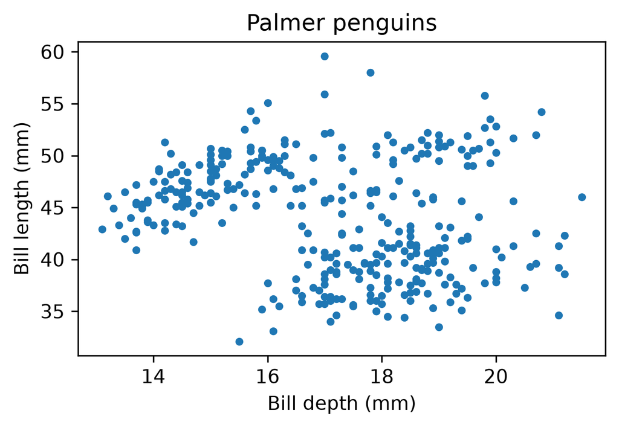

```python
fig, ax = plt.subplots(figsize=(5, 3))
ax.scatter(
  "bill_depth_mm", "bill_length_mm",
  data=penguins, s=10
)
ax.set_xlabel("Bill depth (mm)")
ax.set_ylabel("Bill length (mm)")
ax.set_title("Palmer penguins")
```

The OO approach is generally preferred.

## Subplots (OO)

`plt.subplots(nrows, ncols)` returns a Figure and its Axes. Each panel is drawn and labeled through its own object; the figure-wide title belongs to the Figure.

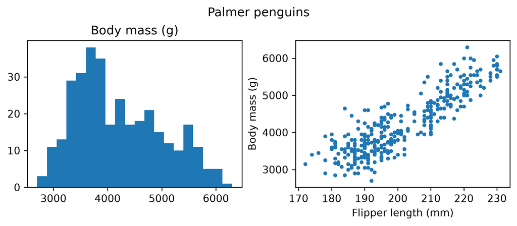

```python
fig, axs = plt.subplots(
  1, 2, figsize=(7, 3),
  layout="constrained"
)
axs[0].hist(
  penguins["body_mass_g"], bins=20
)
axs[0].set_title("Body mass (g)")

axs[1].scatter(
  "flipper_length_mm", "body_mass_g",
  data=penguins, s=8
)
axs[1].set(
  xlabel="Flipper length (mm)",
  ylabel="Body mass (g)"
)
fig.suptitle("Palmer penguins")
```

`axs` is a NumPy array of `Axes` objects, 1D for a single row or column and 2D for a grid. With one panel a single `Axes` is returned instead, and `squeeze=False` always gives a 2D array.

## Subplots (implicit)

`plt.subplot(nrows, ncols, index)` adds the panel at `index` (counting from 1, by row) and makes it the current Axes; subsequent `plt.*` calls draw into whichever panel was selected last.

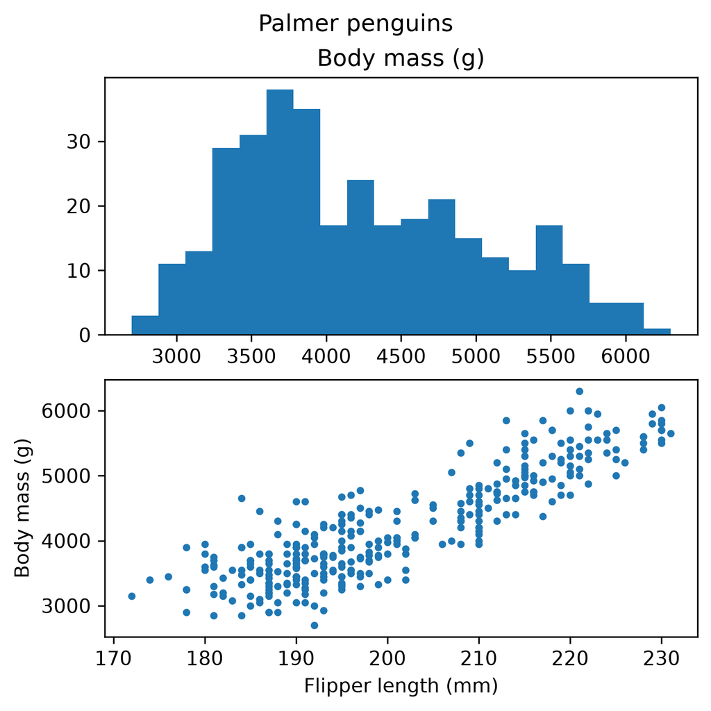

```python
plt.figure(
  figsize=(5, 5), layout="constrained"
)
plt.subplot(2, 1, 1)
plt.hist(
  penguins["body_mass_g"], bins=20
)
plt.title("Body mass (g)")

plt.subplot(2, 1, 2)
plt.scatter(
  "flipper_length_mm", "body_mass_g",
  data=penguins, s=8
)
plt.xlabel("Flipper length (mm)")
plt.ylabel("Body mass (g)")
plt.suptitle("Palmer penguins")
```

## Grouping by hand

matplotlib draws what it is told: `ax.scatter()` takes arrays and either a single color or numeric values run through a colormap (`c=`, `cmap=`). There is no notion of mapping a categorical variable to color, so coloring by species means splitting the data, drawing each subset with a `label`, and asking for a legend. Every additional variable (shape by sex, one panel per island) is another loop.

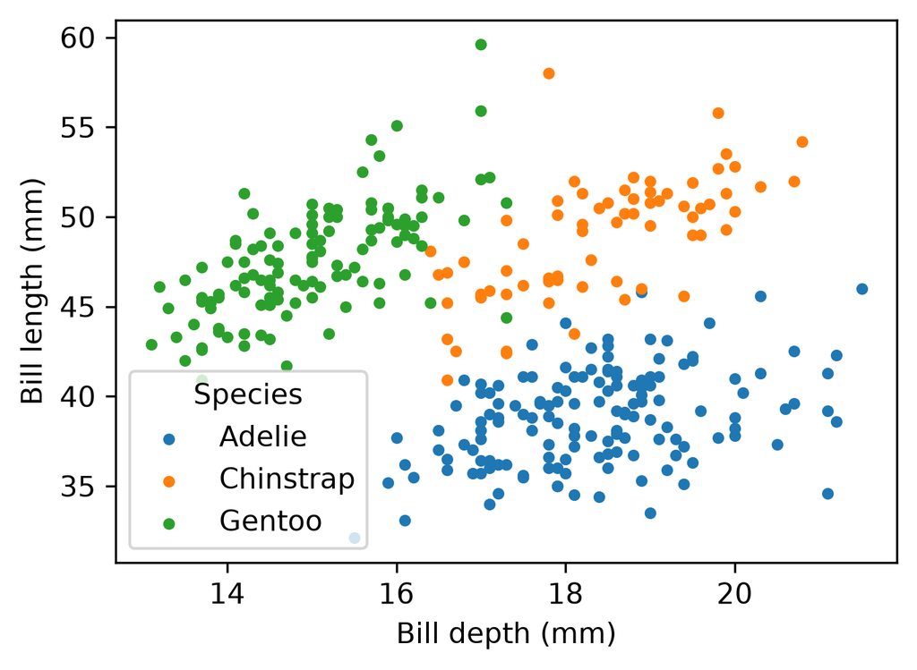

```python
fig, ax = plt.subplots(figsize=(5, 3.5))
for s, d in penguins.groupby("species"):
    ax.scatter(
      "bill_depth_mm", "bill_length_mm",
      data=d, label=s, s=10
    )
ax.set_xlabel("Bill depth (mm)")
ax.set_ylabel("Bill length (mm)")
ax.legend(title="Species")
```

## Format strings

`ax.plot()` accepts a format string, `"[marker][line][color]"`, as shorthand for the `marker`, `linestyle`, and `color` keywords. Each part is optional.

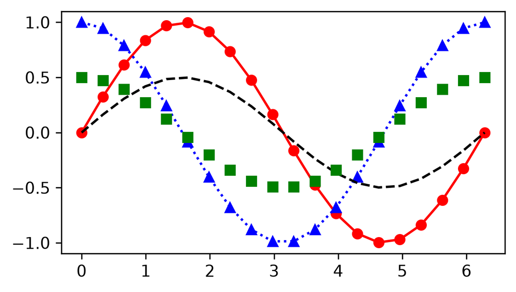

```python
import numpy as np
x = np.linspace(0, 2 * np.pi, 20)

fig, ax = plt.subplots(figsize=(5, 2.75))
ax.plot(x, np.sin(x), "o-r")
ax.plot(x, np.cos(x), "^:b")
ax.plot(x, np.sin(x) / 2, "--k")
ax.plot(x, np.cos(x) / 2, "sg")
```

|  | marker |  | line |  | color |
| --- | --- | --- | --- | --- | --- |
| `.` | point | `-` | solid | `r` | red |
| `o` | circle | `--` | dashed | `g` | green |
| `s` | square | `-.` | dash-dot | `b` | blue |
| `D` | diamond | `:` | dotted | `c` | cyan |
| `^` | triangle up |  |  | `m` | magenta |
| `v` | triangle down |  |  | `y` | yellow |
| `+` | plus |  |  | `k` | black |
| `x` | cross |  |  | `w` | white |
| `*` | star |  |  | `C0`-`C9` | cycle |

See the Notes section of the [`Axes.plot()`](https://matplotlib.org/stable/api/_as_gen/matplotlib.axes.Axes.plot.html) documentation for the full list of markers, line styles, and colors.

# seaborn

## seaborn

> Seaborn is a library for making statistical graphics in Python. It builds on top of matplotlib and integrates closely with pandas data structures. … Its plotting functions operate on dataframes and arrays containing whole datasets and internally perform the necessary semantic mapping and statistical aggregation to produce informative plots. Its dataset-oriented, declarative API lets you focus on what the different elements of your plots mean, rather than on the details of how to draw them.

```python
import seaborn as sns
sns.set_theme()
```

`sns.set_theme()` applies seaborn’s default style, context, and palette to every subsequent matplotlib figure.

## Semantic mappings

`hue` is seaborn’s name for a color mapping, the equivalent of ggplot2’s `color` aesthetic. Python has no data masking, so variables are strings naming columns in `data`.

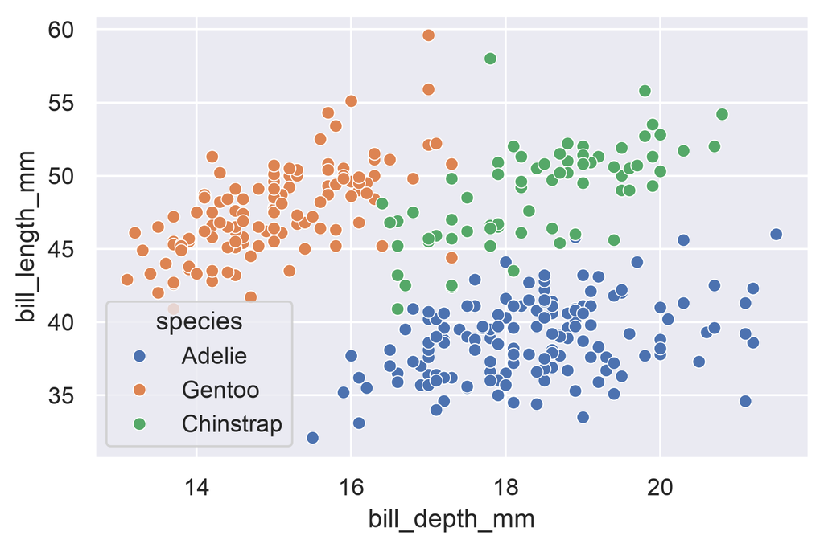

```python
sns.scatterplot(
  data=penguins,
  x="bill_depth_mm",
  y="bill_length_mm",
  hue="species"
)
```

`data` can be a pandas DataFrame, a dict of arrays or lists, or another DataFrame such as polars (converted to pandas). See [data structures accepted by seaborn](https://seaborn.pydata.org/tutorial/data_structure.html).

## Figure-level vs axes-level functions

seaborn’s plotting functions come in two flavors:

- axes-level functions (`scatterplot()`, `histplot()`, `boxplot()`, …) draw one plot on a matplotlib `Axes` (the current one, or one passed as `ax=`) and return that `Axes`, so they mix freely with matplotlib code.
- figure-level functions (`relplot()`, `displot()`, `catplot()`) create their own `Figure`, axes-level function are choosen via `kind=`, faceting via `col=` and `row=`, with a legend placed outside, and return a `FacetGrid`.

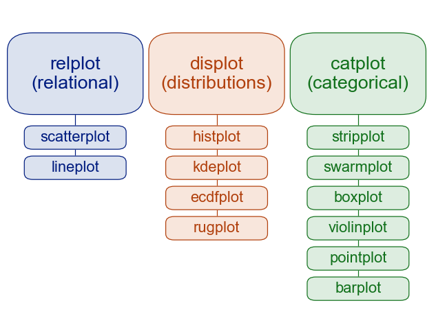

## `relplot()`

`relplot()` shows the relationship between two numeric variables, with `kind="scatter"` (the default) or `kind="line"`. A line plot aggregates rows that share an `x` value, drawing their mean and a 95% bootstrap CI.

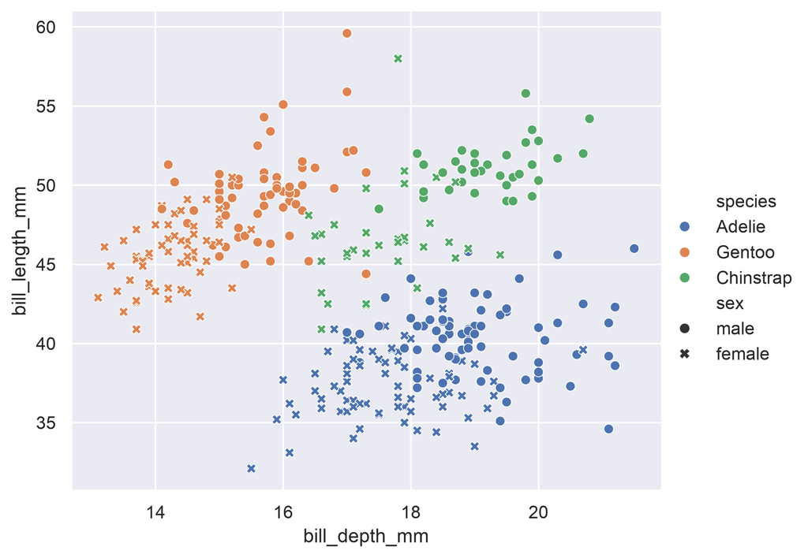

```python
g = sns.relplot(
  data=penguins, x="bill_depth_mm",
  y="bill_length_mm", hue="species",
  style="sex", height=5, aspect=1.2
)
```

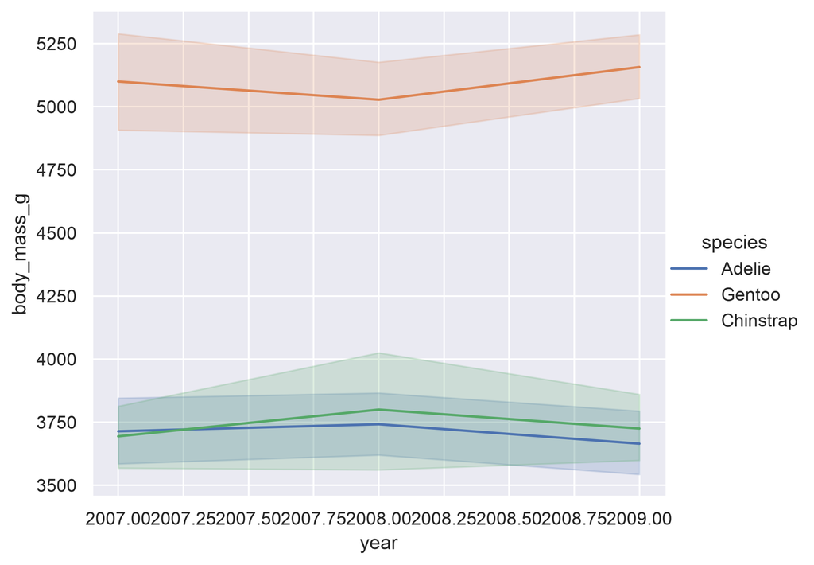

```python
g = sns.relplot(
  data=penguins, x="year",
  y="body_mass_g", hue="species",
  kind="line", height=5, aspect=1.2
)
```

## `displot()`

`displot()` shows the distribution of a numeric variable, with `kind="hist"` (the default), `"kde"`, or `"ecdf"`.

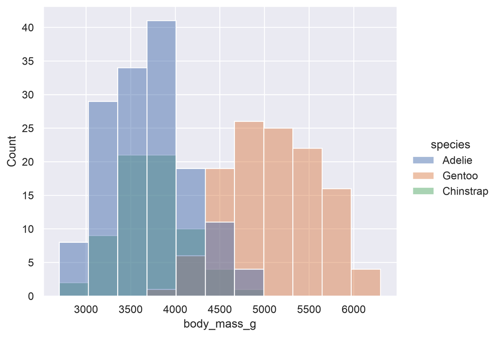

```python
g = sns.displot(
  data=penguins, x="body_mass_g",
  hue="species",
  height=5, aspect=1.2
)
```

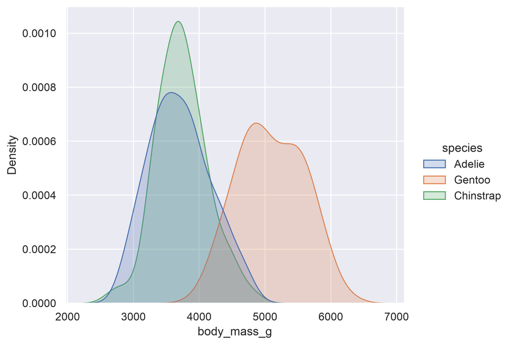

```python
g = sns.displot(
  data=penguins, x="body_mass_g",
  hue="species", kind="kde", fill=True,
  common_norm=False,
  height=5, aspect=1.2
)
```

With `hue`, seaborn defaults to scaling density areas by group size. Use `common_norm=False` to normalize each group independently, as ggplot2 does.

## `catplot()`

`catplot()` shows data grouped by the levels of a categorical variable, with `kind="strip"` (the default), `"box"`, `"violin"`, `"bar"`, and others.

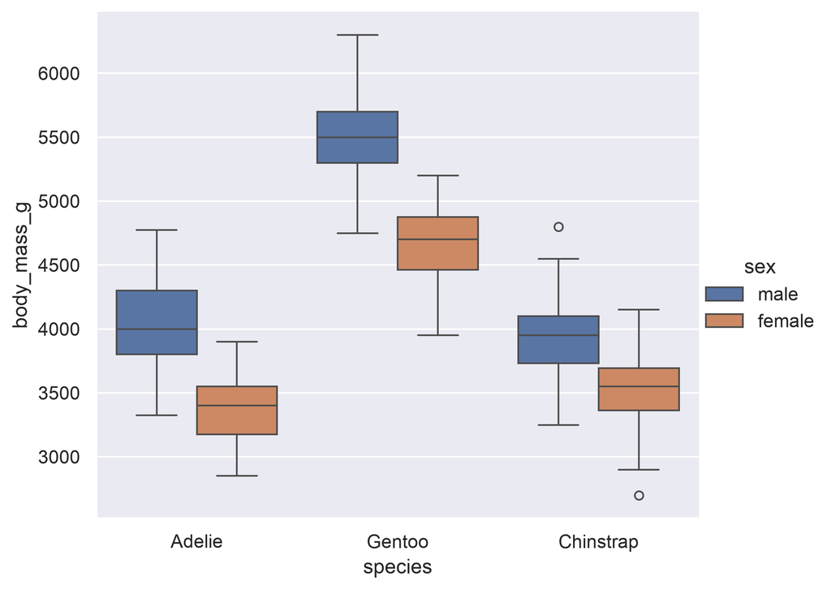

```python
g = sns.catplot(
  data=penguins, x="species",
  y="body_mass_g", hue="sex",
  kind="box", height=5, aspect=1.2
)
```

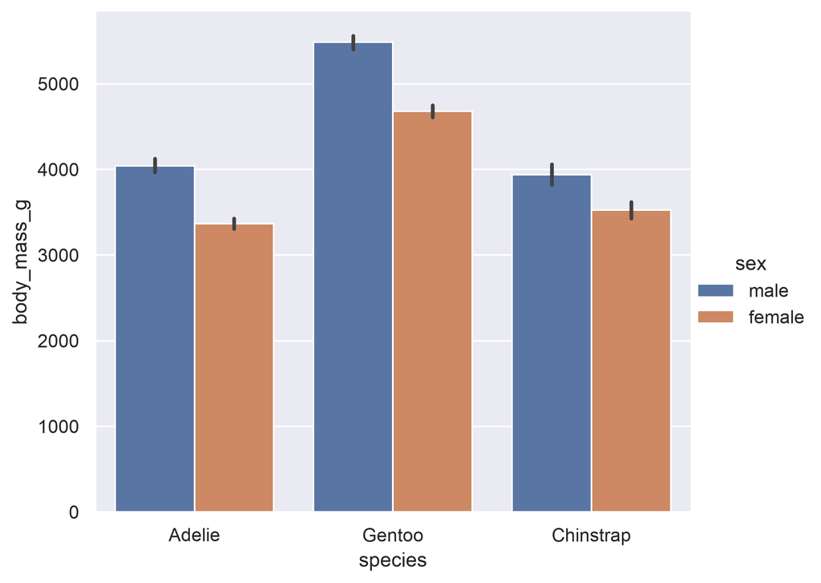

```python
g = sns.catplot(
  data=penguins, x="species",
  y="body_mass_g", hue="sex",
  kind="bar", height=5, aspect=1.2
)
```

Bars can represent different quantities: `geom_bar()` and `catplot(kind="count")` count observations; `catplot(kind="bar")` estimates means by default, with a 95% bootstrap CI as the error bar; `geom_col()` draws values already computed.

## `lmplot()`

`lmplot()` draws a scatterplot with a fitted regression line and its 95% confidence band, the equivalent of `geom_point() + geom_smooth(method = "lm")`. With `hue` there is one fit per group.

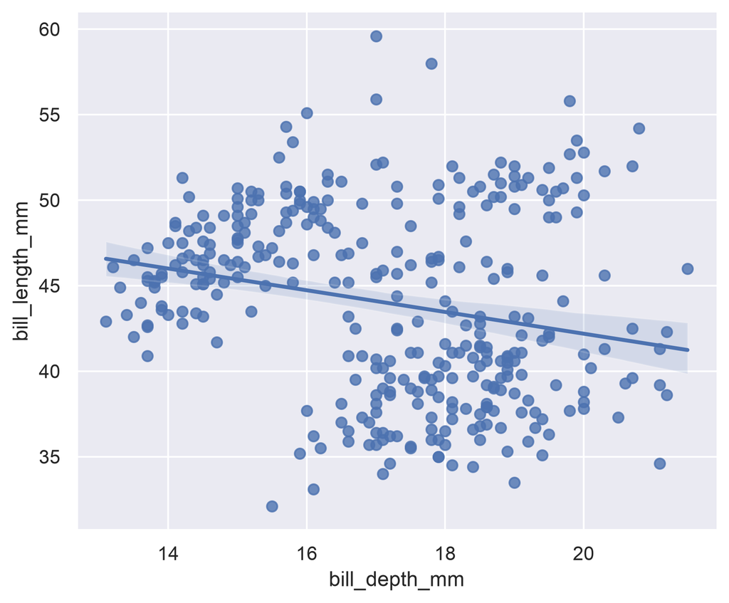

```python
g = sns.lmplot(
  data=penguins, x="bill_depth_mm",
  y="bill_length_mm",
  height=5, aspect=1.2
)
```

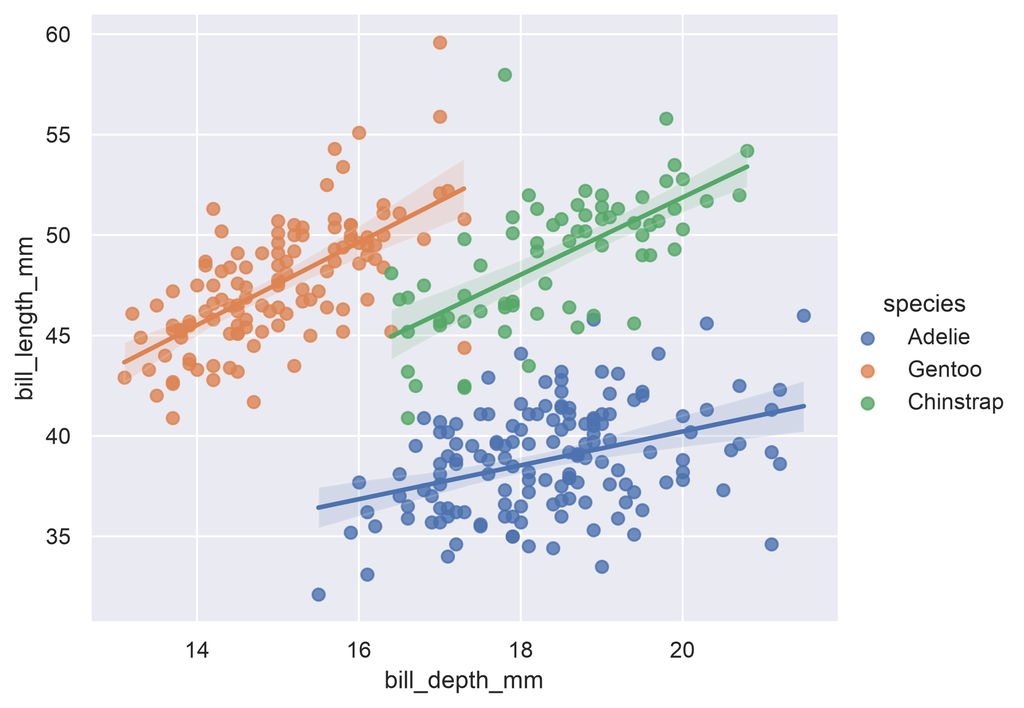

```python
g = sns.lmplot(
  data=penguins, x="bill_depth_mm",
  y="bill_length_mm", hue="species",
  height=5, aspect=1.2
)
```

## Faceting

Figure-level functions facet with `col=`, `row=`, and `col_wrap=`. Panel size is set by `height` and `aspect`, not `figsize`.

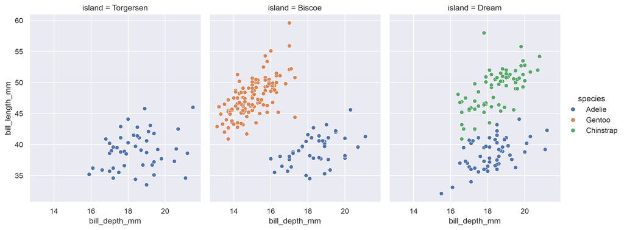

```python
g = sns.relplot(
  data=penguins, x="bill_depth_mm", y="bill_length_mm",
  hue="species", col="island",
  height=5, aspect=0.8
)
```

## Customizing a `FacetGrid`

`FacetGrid` methods cover common tweaks and chain; anything else goes through the wrapped matplotlib objects (`g.axes`, `g.figure`).

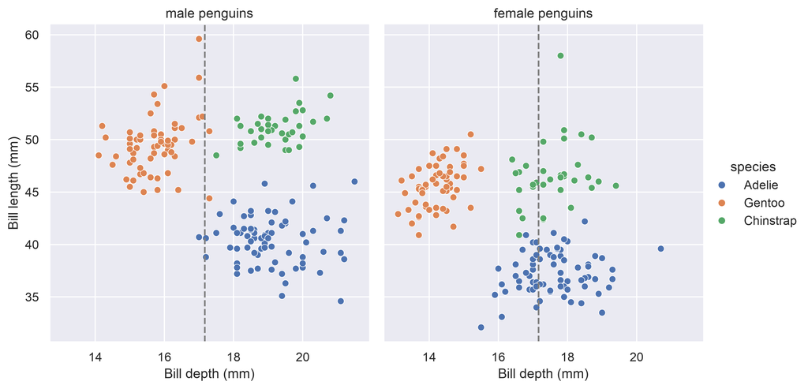

```python
g = sns.relplot(
  data=penguins, x="bill_depth_mm",
  y="bill_length_mm", hue="species",
  col="sex", height=5, aspect=0.9
).set_axis_labels(
  "Bill depth (mm)", "Bill length (mm)"
).set_titles(
  "{col_name} penguins"
)

for ax in g.axes.flat:
    ax.axvline(
      penguins["bill_depth_mm"].mean(),
      color="grey", ls="--"
    )
```

## Axes-level functions

You already have `fig, axs = plt.subplots(1, 2)`. Which function can draw into `axs[0]`: `sns.scatterplot()` or `sns.relplot()`?

Because axes-level functions take an `ax=` argument, they can draw into any figure: several can share a `plt.subplots()` grid alongside plain matplotlib content. Their legend is placed inside the axes.

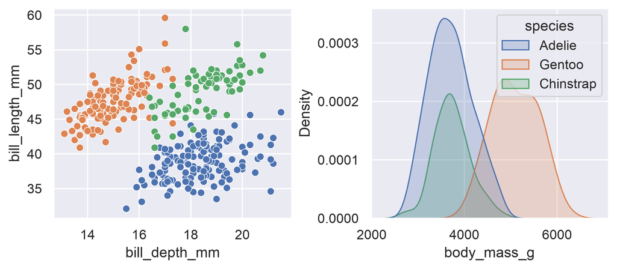

```python
fig, axs = plt.subplots(
  1, 2, figsize=(7, 3),
  layout="constrained"
)
sns.scatterplot(
  data=penguins, x="bill_depth_mm",
  y="bill_length_mm", hue="species",
  ax=axs[0]
)
sns.kdeplot(
  data=penguins, x="body_mass_g",
  hue="species", fill=True,
  ax=axs[1]
)
axs[0].get_legend().remove()
```